# lab4

Derek Maldonado

3/9/2021

## Q1:

Consider the following example data for a between-subjects experiment with two groups, A and B,

Use R to conduct a t.test and ANOVA on this data. Then use R to prove that the results of both analyses are the same. For example, prove that the p-values are the same, and prove that the F-value and T-value are related

```r
library(tibble)
data1 <- c(2,4,3,5,4)
data2 <- c(7,6,5,6,7)

data4q <- tibble(Group = rep(c("A","B"),each = 5),
                 DV = c(data1,data2))

ano <- aov(formula = DV ~ Group, data = data4q)
mysum <- summary(ano)

ttes <- t.test(data1,data2, var.equal = TRUE)

(ttes$statistic)^2
```

```
##    t
## 16.9
```

```r
mysum[[1]]$'F value'
```

```
## [1] 16.9   NA
```

```r
ttes$p.value
```

```
## [1] 0.003386143
```

```r
mysum[[1]]$'Pr(>F)'
```

```
## [1] 0.003386143          NA
```

```r
#100% did take a while to remember how to do a t.test correctly
```

## Q2:

Look at the lab on ANOVA that I wrote for our undergraduate statistics OER lab manual https://crumplab.github.io/statisticsLab/lab-8-one-way-anova.html. That lab shows an example of obtaining data from a published paper in psych science where a one-factor ANOVA was used as a part of the analysis. Load the data, conduct the ANOVA, report a ggplot of the means, and use papaja to help you write a short results section reporting the ANOVA result.

```r
library(readr)
library(dplyr)
```

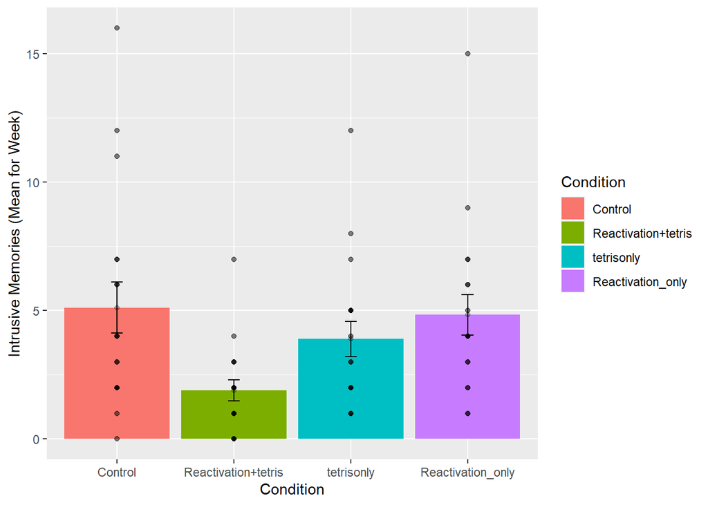

```r
library(ggplot2)
library(data.table)
library(papaja)
tetris <- read_csv("tetris.csv")
tetris$Condition <- as.factor(tetris$Condition)
levels(tetris$Condition) <- c("Control",
                              "Reactivation+tetris",
                              "tetrisonly",
                              "Reactivation_only")

plottin <- tetris%>%
  group_by(Condition) %>%
  summarise(means = mean(Days_One_to_Seven_Number_of_Intrusions),
            SE = sd(Days_One_to_Seven_Number_of_Intrusions)/sqrt(length(Days_One_to_Seven_Number_of_Intrusions)))

ggplot(plottin, aes(x=Condition, y=means))+
  geom_bar(stat="identity", aes(fill=Condition))+
  geom_errorbar(aes(ymin=means-SE,
                    ymax=means+SE), width=.1) +
  geom_point(data=tetris, aes(x=Condition, y=Days_One_to_Seven_Number_of_Intrusions), alpha=.5)+
  geom_point(alpha=.25)+
  ylab("Intrusive Memories (Mean for Week)")
```

```r
#ggplot(tetris, aes(x=Condition,
#                   y=Days_One_to_Seven_Number_of_Intrusions))+
#  geom_bar(stat="summary",fun="mean", position="dodge")+
#  geom_point()

q2data <- aov(Days_One_to_Seven_Number_of_Intrusions ~ Condition, tetris)
summary(q2data)
```

```
##             Df Sum Sq Mean Sq F value Pr(>F)
## Condition    3  114.8   38.27   3.795 0.0141 *
## Residuals   68  685.8   10.09
## ---
## Signif. codes:  0 '***' 0.001 '**' 0.01 '*' 0.05 '.' 0.1 ' ' 1
```

```r
apa_table(apa_print(q2data)$table)
```

| Effect | $F$ | $\mathit{df}_1$ | $\mathit{df}_2$ | $\mathit{MSE}$ | $p$ | $\hat{\eta}^2_G$ |
| --- | --- | --- | --- | --- | --- | --- |
| Condition | 3.79 | 3 | 68 | 10.09 | .014 | .143 |

```r
#75% didn't really understand how to do the fancy write up at the end, also completely forgot how to inline r code in my writing
```

We developed a one-factor between-subjects ANOVA to examine the mean intrusive memories for the week from each participant. We found an effect of intervention type, $F(3, 68) = 3.79$, $\mathit{MSE} = 10.09$, $p = .014$, $\hat{\eta}^2_G = .143$.